# A3: Incarceration

### Introduction

I am analyzing racial incarcerated prison populations over time throughout USA and specifically King County, WA. King County, WA is the biggest county in WA and known to have the biggest population out of all Washington counties. Which is why I have chosen this specific county for my first data set.

### Summary Information

Summary information that I wanted to include along with my charts is that there was an average of 1280 Black Americans who were incarcerated in King County, WA by 2016. Within that same year, there were 1489 White Americans, 64 Asian Americans and Pacific Islander Americans, 139 Latinx Americans, 112 Native Americans and 234 Americans who were mixed race or had other racial identities who were incarcerated in King County, WA.

### The Dataset

Who collected the data? Vera collected the data.

How was the data collected or generated?  
The data collection was from the US Department of Bureau of Justice.

Why was the data collected? The data was collected to show the amount of incarcerated people in USA and where they are all located and as well as their race.

How many observations (rows) are in your data?  
There are 153811 observations(rows) in the data set.

How many features (columns) are in the data? There are 121 columns in the data set.

What, if any, ethical questions or questions of power do you need to consider when working with this data?  
Questions of power that I need to consider when working with this data is that people who are of power in USA might skew the data by putting minorities or people of color in the criminal system because of a racial motive or bias. There might be an unequal amount of people of color represented in the data set due to racism.

### Trends Over Time Chart

I included a chart regarding White Americans and Black Americans over the years because I noticed that there was a spike in the incarcerated Black American population by 1991 in King County, WA. From there, more and more Black Americans became incarcerated each year. There was a lot of Black Americans incarcerated by the year 2002 compared to White Americans. Though I do not know the historical significance of this data, I was thinking that this could be due to racism and racial bias. I decided to include specifically King County, Wa because it was the location that I related to the most and King County is the biggest county in Washington.

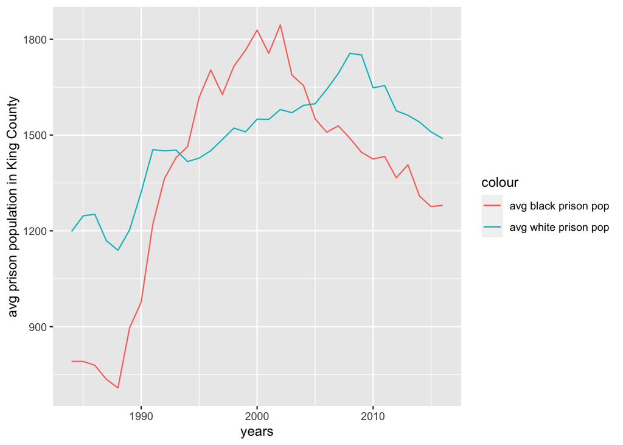

### Variable Comparison Chart

I included a chart regarding the comparison between Incarcerated Black Women and Men because I wanted to see the population was fully made regarding these two known variables of gender. Though there could be more gender identifiers, this graph compares the population of Incarcerated Black Women and Black Men.

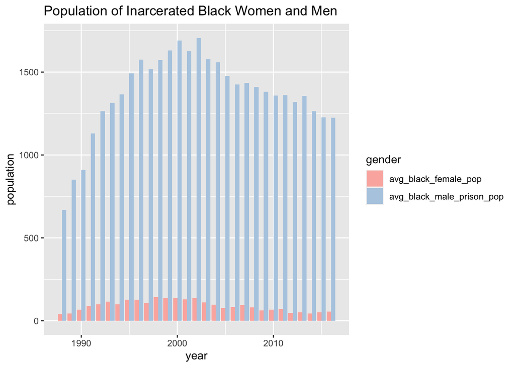

### Map

I included a map of the average Black American Incarceration Population in the USA because I wanted to show how much Black Americans were being incarcerated in each state and how those numbers compare to other states.

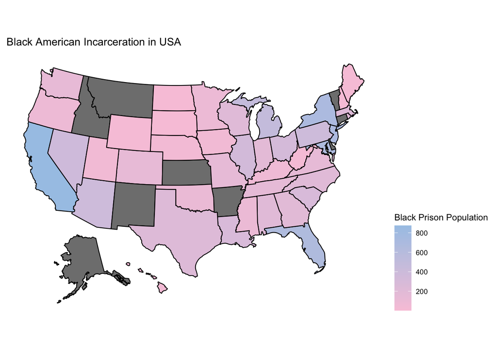